# Introduction

# EDA

```r
install.packages("ggthemes", repos = 'http://cran.us.r-project.org')
library(ggthemes)
```

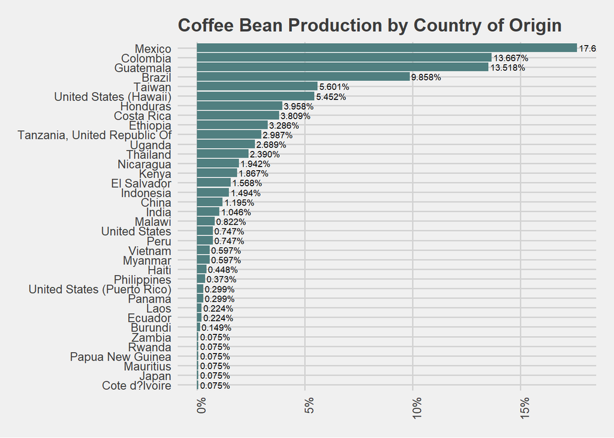

```r
country_table<-coffee_ratings %>%
    count(country_of_origin = factor(country_of_origin)) %>%
    mutate(pct = prop.table(n)) %>%
    arrange(-pct) %>%
    tibble()

ggplot(
  country_table %>% filter(country_of_origin != "NA"),
  mapping = aes(
    x = reorder(country_of_origin, n),
    y = pct,
    group = 1,
    label = scales::percent(pct)
  )
) +
  theme_fivethirtyeight() +
  geom_bar(stat = "identity",
           fill = "#507F80") +
  geom_text(position = position_dodge(width = 0.8),
            hjust = -0.05,
            size = 2.5) +
  labs(x = "Country of Origin",
       y = "Proportion of Dataset") +
  theme(axis.text.x = element_text(
    angle = 90,
    vjust = 0.9,
    hjust = 1
  )) +

  ggtitle("Coffee Bean Production by Country of Origin " ) +
  theme(plot.title=element_text(size=15))+
  scale_y_continuous(labels = scales::percent) +
  coord_flip()
```

From the graph, it can be inferred that over 45% of coffee bean is produced by Latin America countries, suc as Mexico, Colombia, Guatemala and Brazil. Then, we will see, how the proportion of the species of the coffee bean. Between robusta and arabica, which one more popular.

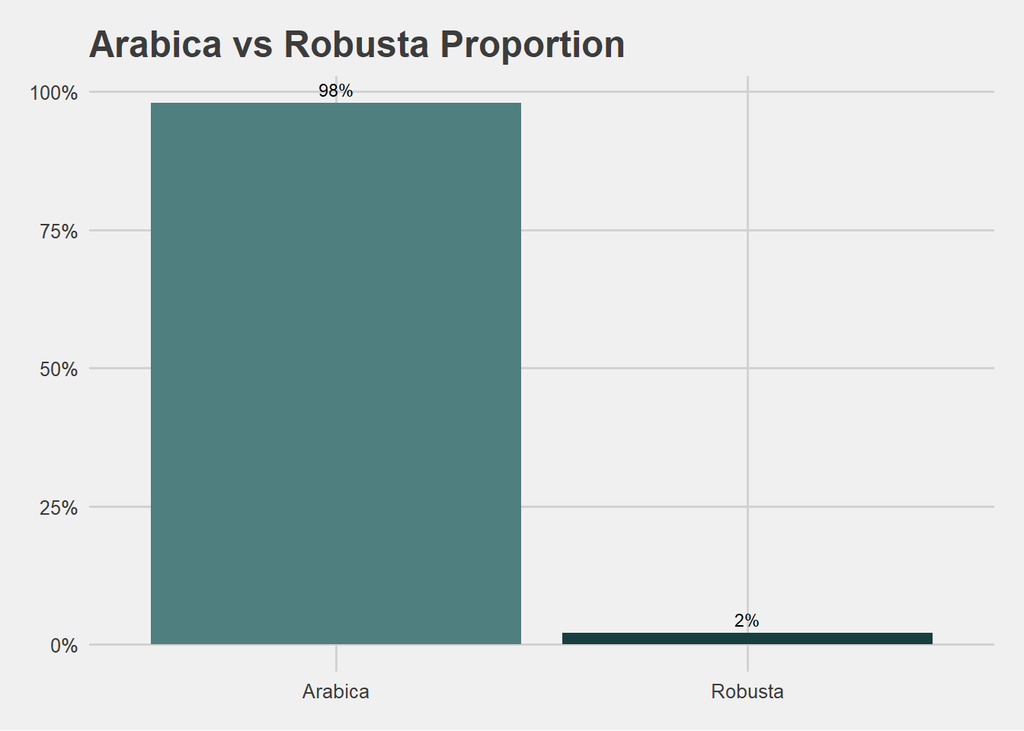

```r
species_table<-coffee_ratings %>%
    count(species = factor(species)) %>%
    mutate(pct = prop.table(n)) %>% tibble()
ggplot(species_table,mapping=aes(x=species,y=pct,group=1,label=scales::percent(pct)))+
   theme_fivethirtyeight()+
  geom_bar(stat="identity",
           fill=c("#507F80","#173F3F"))+
    geom_text(position = position_dodge(width=0.9),
              vjust=-0.5,
              size = 3)+
  scale_y_continuous(labels = scales::percent)+
  ggtitle("Arabica vs Robusta Proportion")
```

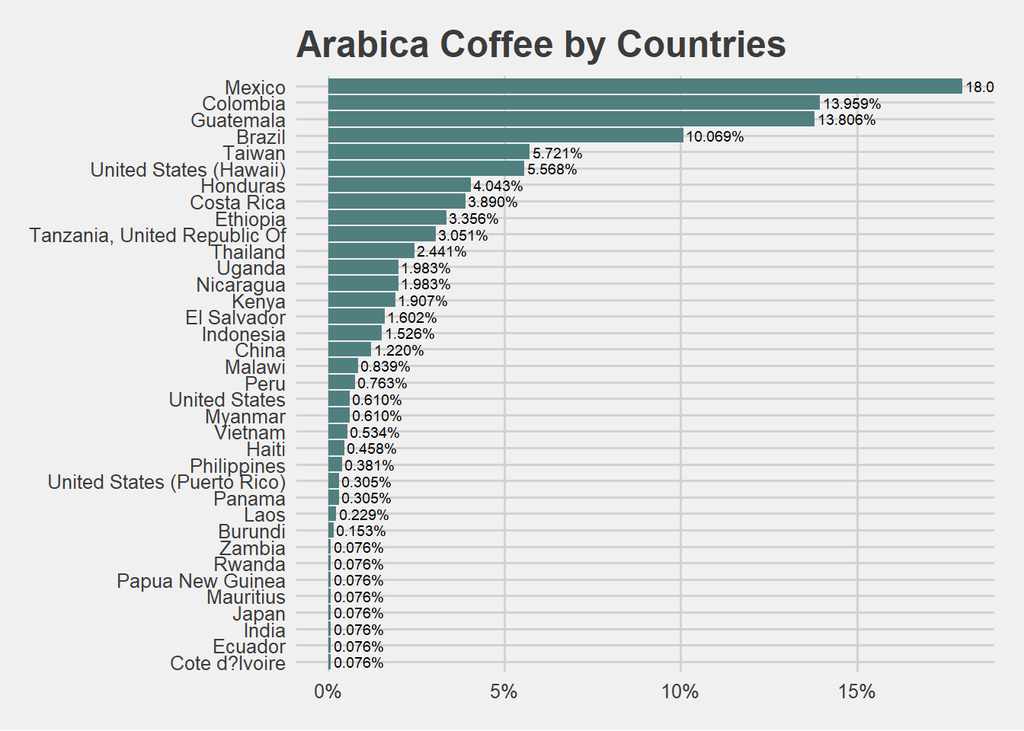

```r
arabica_countries<-coffee_ratings %>%
  filter(species =="Arabica") %>%
    count(species=factor(species),
          country=country_of_origin) %>%
    mutate(pct = prop.table(n)) %>%
    arrange(-n) %>%
  tibble()

ggplot(arabica_countries %>% filter(country!="NA"),
       mapping=aes(x=reorder(country,n),y=pct,group=1,label=scales::percent(pct))) +
  theme_fivethirtyeight()+
  geom_bar(stat="identity",
           fill="#507F80")+
  geom_text(position = position_dodge(width = 0.9),
            hjust = -0.05,
            size = 2.5) +
  ggtitle("Arabica Coffee by Countries") +
   scale_y_continuous(labels = scales::percent) +
  coord_flip()
```

Mexico is the highest producer of the coffee bean with occupied 18% of the total production, followed by Colombia and Guatemala with 13% and Brazil with 10%.

```r
robusta_countries<-coffee_ratings %>%
    filter(species =="Robusta") %>%
    count(species = factor(species),
          country=country_of_origin) %>%
    mutate(pct = prop.table(n)) %>%
    arrange(-n) %>%
  tibble()
```

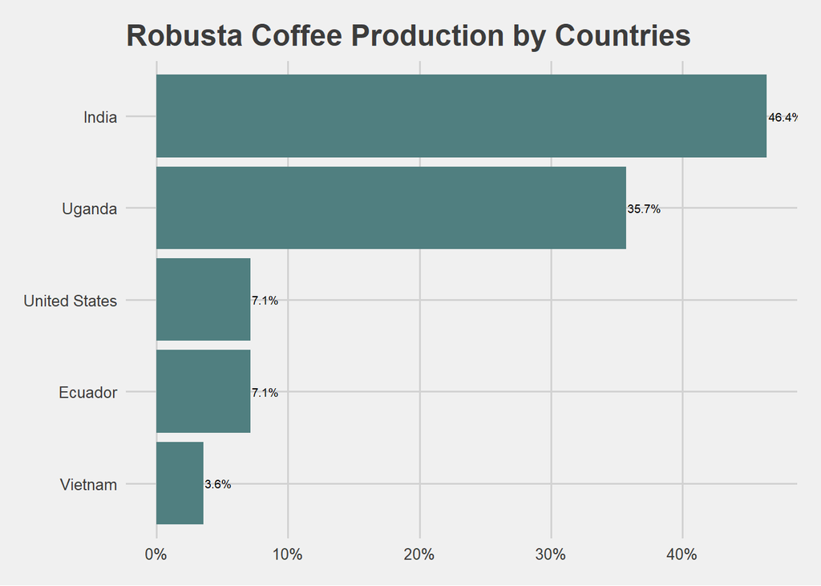

```r
ggplot(robusta_countries %>% filter(country!="NA"),
       mapping=aes(x=reorder(country,n),y=pct,group=1,label=scales::percent(pct))) +
  theme_fivethirtyeight()+
  geom_bar(stat="identity",
           fill="#507F80")+
  geom_text(position = position_dodge(width = 0.9),
            hjust = -0.05,
            size = 2.5) +
  ggtitle("Robusta Coffee Production by Countries") +
   scale_y_continuous(labels = scales::percent) +
  coord_flip()
```

Robusta bean is mainly produced by India (46.4%), Uganda (35.7%), United States and Ecuador with 7%, and finally Vietnam with 3.6%.

```r
coffee_ratings %>%
  filter(country_of_origin %in% c("India","Uganda","Ecuador","United States","Vietnam")) %>%
  count(country_of_origin,species) %>%
  group_by(country_of_origin)
```

```
## # A tibble: 10 × 3
## # Groups:   country_of_origin [5]
##    country_of_origin species     n
##    <fct>             <fct>   <int>
##  1 Ecuador           Arabica     1
##  2 Ecuador           Robusta     2
##  3 India             Arabica     1
##  4 India             Robusta    13
##  5 Uganda            Arabica    26
##  6 Uganda            Robusta    10
##  7 United States     Arabica     8
##  8 United States     Robusta     2
##  9 Vietnam           Arabica     7
## 10 Vietnam           Robusta     1
```

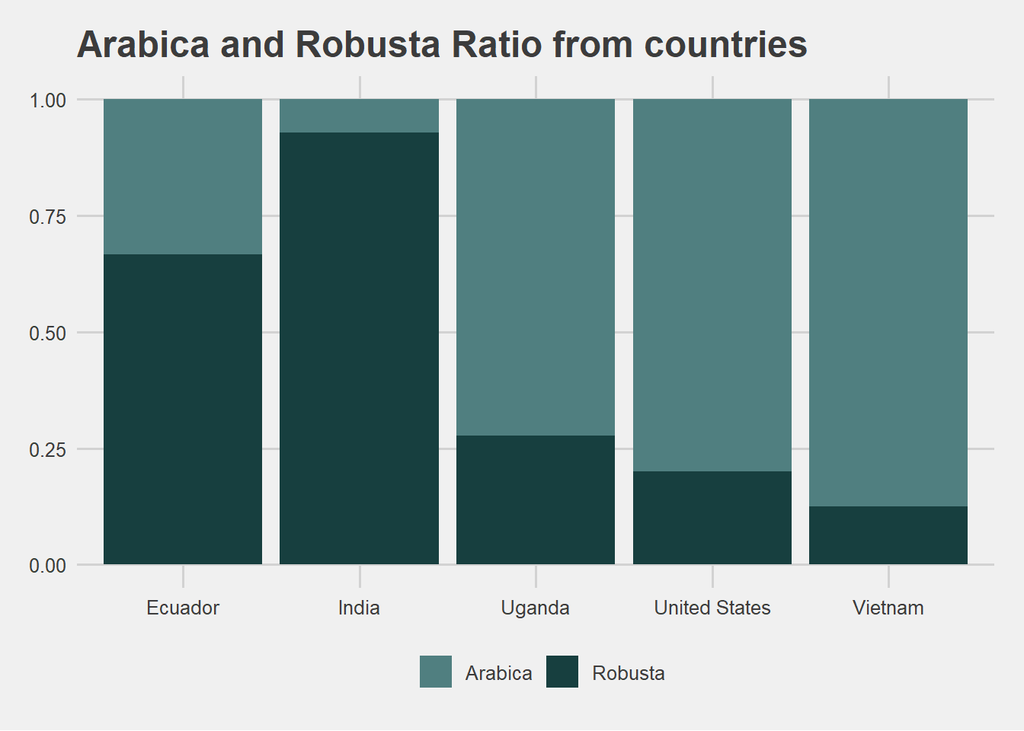

```r
ggplot(coffee_ratings %>% filter(country_of_origin %in% c("India","Uganda","Ecuador","United States","Vietnam")),
       mapping=aes(x=country_of_origin,fill=species))+
  theme_fivethirtyeight()+
  geom_bar(position="fill")+
  scale_fill_manual(values=c("#507F80","#173F3F"))+
  theme(legend.title = element_blank())+
  ggtitle("Arabica and Robusta Ratio from countries ")
```

Although India is the main producer of Robusta coffee bean, but India also produce Arabica with around 10% of the country production, and even Vietnam, Uganda and United states also produce more Arabica coffe bean than Robusta coffee bean.

```r
library(lubridate)
```

# Getting the year data

```r
coffee_ratings$new_dates<-coffee_ratings$grading_date %>% mdy()
coffee_ratings$score_year<- coffee_ratings$new_dates %>% year()
```

# Data set for vizualisation

```r
  top_annual_score<- coffee_ratings %>%
  group_by(species,
           score_year,
           country_of_origin) %>%
  summarise(max_points = max(total_cup_points)) %>%
  filter(max_points == max(max_points)) %>%
  arrange(-max_points)
```

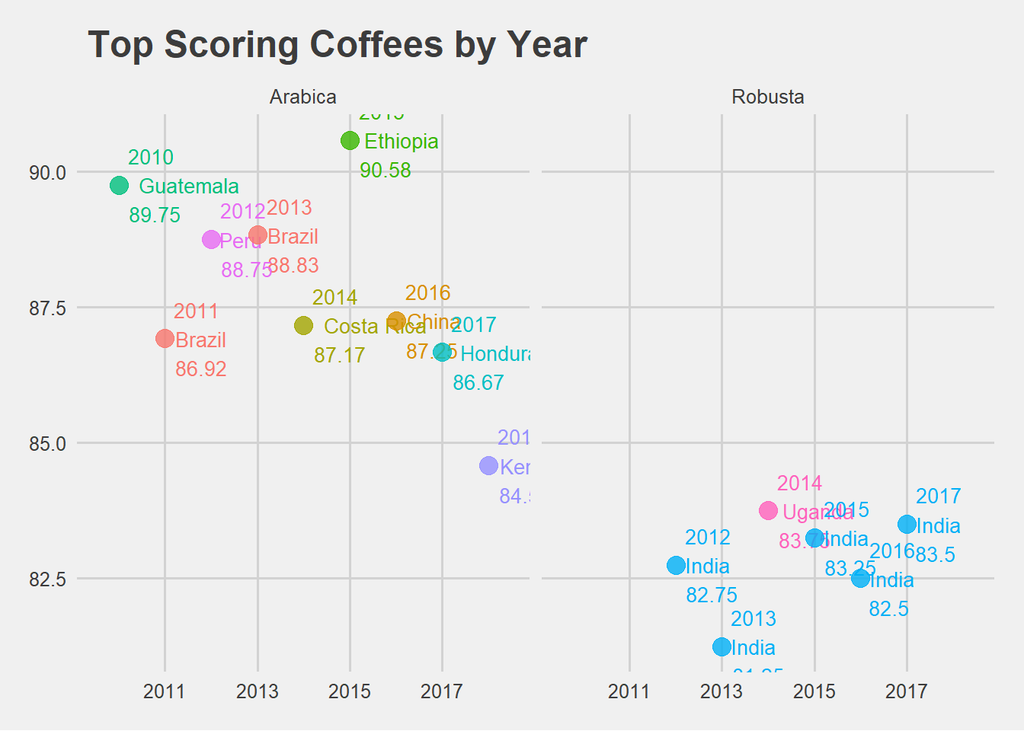

```r
ggplot(top_annual_score,
       mapping=aes(x=score_year,
                   y=max_points,
                   label=paste0(score_year,"\n",country_of_origin,"\n", max_points),
                   color=country_of_origin))+
  theme_fivethirtyeight()+
  geom_text(position = position_dodge(width = 0.9),
            hjust =-0.2,
            size =3.5) +
  geom_point(size=4,
             alpha=0.8)+
  theme(legend.position = "none")+
  facet_wrap(~species)+
  ggtitle(" Top Scoring Coffees by Year  ")
```

The graph give us a glimpse of the production of the coffee bean year by year based on the species (Robusta and Arabica). Arabica beans from Ethiopia scored the highest with a score of 90.58 and for Robusta Beans Uganda had the highest score of 83.75.

# Removing irrelavant variables

```r
coffee_new <-coffee_ratings %>%
  select(total_cup_points, species, country_of_origin, region, altitude, producer, variety, aroma, processing_method, flavor, aftertaste, acidity, body, balance, uniformity, clean_cup, sweetness,cupper_points, moisture, category_one_defects, category_two_defects, quakers, color, altitude_low_meters, altitude_mean_meters, altitude_high_meters)
glimpse(coffee_new)
```

```
## Rows: 1,339
## Columns: 26
## $ total_cup_points     <dbl> 90.58, 89.92, 89.75, 89.00, 88.83, 88.83, 88.75, …
## $ species              <fct> Arabica, Arabica, Arabica, Arabica, Arabica, Arab…
## $ country_of_origin    <fct> "Ethiopia", "Ethiopia", "Guatemala", "Ethiopia", …
## $ region               <fct> "guji-hambela", "guji-hambela", NA, "oromia", "gu…
## $ altitude             <fct> 1950-2200, 1950-2200, 1600 - 1800 m, 1800-2200, 1…
## $ producer             <fct> "METAD PLC", "METAD PLC", NA, "Yidnekachew Dabess…
## $ variety              <fct> NA, Other, Bourbon, NA, Other, NA, Other, NA, NA,…
## $ aroma                <dbl> 8.67, 8.75, 8.42, 8.17, 8.25, 8.58, 8.42, 8.25, 8…
## $ processing_method    <fct> Washed / Wet, Washed / Wet, NA, Natural / Dry, Wa…
## $ flavor               <dbl> 8.83, 8.67, 8.50, 8.58, 8.50, 8.42, 8.50, 8.33, 8…
## $ aftertaste           <dbl> 8.67, 8.50, 8.42, 8.42, 8.25, 8.42, 8.33, 8.50, 8…
## $ acidity              <dbl> 8.75, 8.58, 8.42, 8.42, 8.50, 8.50, 8.50, 8.42, 8…
## $ body                 <dbl> 8.50, 8.42, 8.33, 8.50, 8.42, 8.25, 8.25, 8.33, 8…
## $ balance              <dbl> 8.42, 8.42, 8.42, 8.25, 8.33, 8.33, 8.25, 8.50, 8…
## $ uniformity           <dbl> 10.00, 10.00, 10.00, 10.00, 10.00, 10.00, 10.00, …
## $ clean_cup            <dbl> 10, 10, 10, 10, 10, 10, 10, 10, 10, 10, 10, 10, 1…
## $ sweetness            <dbl> 10.00, 10.00, 10.00, 10.00, 10.00, 10.00, 10.00, …
## $ cupper_points        <dbl> 8.75, 8.58, 9.25, 8.67, 8.58, 8.33, 8.50, 9.00, 8…
## $ moisture             <dbl> 0.12, 0.12, 0.00, 0.11, 0.12, 0.11, 0.11, 0.03, 0…
## $ category_one_defects <dbl> 0, 0, 0, 0, 0, 0, 0, 0, 0, 0, 0, 0, 0, 0, 0, 0, 0…
## $ category_two_defects <dbl> 0, 1, 0, 2, 2, 1, 0, 0, 0, 4, 1, 0, 0, 2, 2, 0, 0…
## $ quakers              <dbl> 0, 0, 0, 0, 0, 0, 0, 0, 0, 0, 0, 0, 0, 0, 0, 0, 0…
## $ color                <fct> Green, Green, NA, Green, Green, Bluish-Green, Blu…
## $ altitude_low_meters  <dbl> 1950.0, 1950.0, 1600.0, 1800.0, 1950.0, NA, NA, 1…
## $ altitude_mean_meters <dbl> 2075.0, 2075.0, 1700.0, 2000.0, 2075.0, NA, NA, 1…
## $ altitude_high_meters <dbl> 2200.0, 2200.0, 1800.0, 2200.0, 2200.0, NA, NA, 1…
```

There are some variables dropped from the data set, since irrelevant variables to this analysis.

```r
coffee_relevant <-coffee_ratings %>%
  select(total_cup_points, species, aroma, processing_method, flavor, aftertaste, acidity, body, balance, uniformity, clean_cup, sweetness,cupper_points)
glimpse(coffee_relevant)
```

```
## Rows: 1,339
## Columns: 13
## $ total_cup_points  <dbl> 90.58, 89.92, 89.75, 89.00, 88.83, 88.83, 88.75, 88.…
## $ species           <fct> Arabica, Arabica, Arabica, Arabica, Arabica, Arabica…
## $ aroma             <dbl> 8.67, 8.75, 8.42, 8.17, 8.25, 8.58, 8.42, 8.25, 8.67…
## $ processing_method <fct> Washed / Wet, Washed / Wet, NA, Natural / Dry, Washe…
## $ flavor            <dbl> 8.83, 8.67, 8.50, 8.58, 8.50, 8.42, 8.50, 8.33, 8.67…
## $ aftertaste        <dbl> 8.67, 8.50, 8.42, 8.42, 8.25, 8.42, 8.33, 8.50, 8.58…
## $ acidity           <dbl> 8.75, 8.58, 8.42, 8.42, 8.50, 8.50, 8.50, 8.42, 8.42…
## $ body              <dbl> 8.50, 8.42, 8.33, 8.50, 8.42, 8.25, 8.25, 8.33, 8.33…
## $ balance           <dbl> 8.42, 8.42, 8.42, 8.25, 8.33, 8.33, 8.25, 8.50, 8.42…
## $ uniformity        <dbl> 10.00, 10.00, 10.00, 10.00, 10.00, 10.00, 10.00, 10.…
## $ clean_cup         <dbl> 10, 10, 10, 10, 10, 10, 10, 10, 10, 10, 10, 10, 10, …
## $ sweetness         <dbl> 10.00, 10.00, 10.00, 10.00, 10.00, 10.00, 10.00, 9.3…
## $ cupper_points     <dbl> 8.75, 8.58, 9.25, 8.67, 8.58, 8.33, 8.50, 9.00, 8.67…
```

converting variables to integer

```r
coffee_relevant<- coffee_relevant %>%
  mutate(total_cup_points = as.integer(total_cup_points),
    aroma = as.integer(aroma),
    flavor = as.integer(flavor),
    aftertaste = as.integer(aftertaste),
    acidity= as.integer(acidity),
    body= as.integer(body),
    balance= as.integer(balance),
    uniformity= as.integer(uniformity),
    clean_cup= as.integer(clean_cup),
    sweetness= as.integer(sweetness),
    cupper_points= as.integer(cupper_points))
glimpse(coffee_relevant)
```

```
## Rows: 1,339
## Columns: 13
## $ total_cup_points  <int> 90, 89, 89, 89, 88, 88, 88, 88, 88, 88, 88, 87, 87, …
## $ species           <fct> Arabica, Arabica, Arabica, Arabica, Arabica, Arabica…
## $ aroma             <int> 8, 8, 8, 8, 8, 8, 8, 8, 8, 8, 8, 8, 8, 8, 8, 8, 8, 8…
## $ processing_method <fct> Washed / Wet, Washed / Wet, NA, Natural / Dry, Washe…
## $ flavor            <int> 8, 8, 8, 8, 8, 8, 8, 8, 8, 8, 8, 8, 8, 8, 8, 8, 8, 8…
## $ aftertaste        <int> 8, 8, 8, 8, 8, 8, 8, 8, 8, 8, 8, 8, 8, 8, 8, 8, 7, 8…
## $ acidity           <int> 8, 8, 8, 8, 8, 8, 8, 8, 8, 8, 8, 8, 8, 8, 8, 8, 7, 8…
## $ body              <int> 8, 8, 8, 8, 8, 8, 8, 8, 8, 7, 7, 8, 8, 8, 8, 8, 8, 8…
## $ balance           <int> 8, 8, 8, 8, 8, 8, 8, 8, 8, 8, 8, 8, 8, 8, 8, 8, 8, 8…
## $ uniformity        <int> 10, 10, 10, 10, 10, 10, 10, 10, 9, 10, 10, 10, 10, 1…
## $ clean_cup         <int> 10, 10, 10, 10, 10, 10, 10, 10, 10, 10, 10, 10, 10, …
## $ sweetness         <int> 10, 10, 10, 10, 10, 10, 10, 9, 9, 10, 10, 10, 10, 10…
## $ cupper_points     <int> 8, 8, 9, 8, 8, 8, 8, 9, 8, 8, 8, 8, 8, 8, 8, 8, 8, 8…
```

```r
coffee_relevant<- coffee_relevant %>%
  mutate(total_cup_points = as.numeric(total_cup_points),
    aroma = as.numeric(aroma),
    flavor = as.numeric(flavor),
    aftertaste = as.numeric(aftertaste),
    acidity= as.numeric(acidity),
    body= as.numeric(body),
    balance= as.numeric(balance),
    uniformity= as.numeric(uniformity),
    clean_cup= as.numeric(clean_cup),
    sweetness= as.numeric(sweetness),
    cupper_points= as.numeric(cupper_points))
glimpse(coffee_relevant)
```

```
## Rows: 1,339
## Columns: 13
## $ total_cup_points  <dbl> 90, 89, 89, 89, 88, 88, 88, 88, 88, 88, 88, 87, 87, …
## $ species           <fct> Arabica, Arabica, Arabica, Arabica, Arabica, Arabica…
## $ aroma             <dbl> 8, 8, 8, 8, 8, 8, 8, 8, 8, 8, 8, 8, 8, 8, 8, 8, 8, 8…
## $ processing_method <fct> Washed / Wet, Washed / Wet, NA, Natural / Dry, Washe…
## $ flavor            <dbl> 8, 8, 8, 8, 8, 8, 8, 8, 8, 8, 8, 8, 8, 8, 8, 8, 8, 8…
## $ aftertaste        <dbl> 8, 8, 8, 8, 8, 8, 8, 8, 8, 8, 8, 8, 8, 8, 8, 8, 7, 8…
## $ acidity           <dbl> 8, 8, 8, 8, 8, 8, 8, 8, 8, 8, 8, 8, 8, 8, 8, 8, 7, 8…
## $ body              <dbl> 8, 8, 8, 8, 8, 8, 8, 8, 8, 7, 7, 8, 8, 8, 8, 8, 8, 8…
## $ balance           <dbl> 8, 8, 8, 8, 8, 8, 8, 8, 8, 8, 8, 8, 8, 8, 8, 8, 8, 8…
## $ uniformity        <dbl> 10, 10, 10, 10, 10, 10, 10, 10, 9, 10, 10, 10, 10, 1…
## $ clean_cup         <dbl> 10, 10, 10, 10, 10, 10, 10, 10, 10, 10, 10, 10, 10, …
## $ sweetness         <dbl> 10, 10, 10, 10, 10, 10, 10, 9, 9, 10, 10, 10, 10, 10…
## $ cupper_points     <dbl> 8, 8, 9, 8, 8, 8, 8, 9, 8, 8, 8, 8, 8, 8, 8, 8, 8, 8…
```

## Correlation matrix

```r
cor(coffee_relevant[sapply(coffee_relevant,is.numeric)])
```

```
##                  total_cup_points     aroma    flavor aftertaste   acidity
## total_cup_points        1.0000000 0.6353264 0.7280336  0.7553387 0.6556529
## aroma                   0.6353264 1.0000000 0.6372960  0.5609203 0.5741555
## flavor                  0.7280336 0.6372960 1.0000000  0.7127338 0.6373036
## aftertaste              0.7553387 0.5609203 0.7127338  1.0000000 0.5746968
## acidity                 0.6556529 0.5741555 0.6373036  0.5746968 1.0000000
## body                    0.6085343 0.5027663 0.5650861  0.5226761 0.5442750
## balance                 0.6949189 0.5158712 0.6038243  0.6611978 0.5241857
## uniformity              0.6058842 0.2663255 0.2912416  0.3723384 0.2808299
## clean_cup               0.6390187 0.2615895 0.3692520  0.3889259 0.2640270
## sweetness               0.5047352 0.1899357 0.2439511  0.2484332 0.2187648
## cupper_points           0.6643377 0.4884194 0.6310421  0.6418156 0.5261573
##                       body   balance uniformity clean_cup sweetness
## total_cup_points 0.6085343 0.6949189  0.6058842 0.6390187 0.5047352
## aroma            0.5027663 0.5158712  0.2663255 0.2615895 0.1899357
## flavor           0.5650861 0.6038243  0.2912416 0.3692520 0.2439511
## aftertaste       0.5226761 0.6611978  0.3723384 0.3889259 0.2484332
## acidity          0.5442750 0.5241857  0.2808299 0.2640270 0.2187648
## body             1.0000000 0.5724524  0.2750415 0.2128284 0.2455026
## balance          0.5724524 1.0000000  0.3164733 0.3438233 0.2421780
## uniformity       0.2750415 0.3164733  1.0000000 0.5071835 0.4087085
## clean_cup        0.2128284 0.3438233  0.5071835 1.0000000 0.4078337
## sweetness        0.2455026 0.2421780  0.4087085 0.4078337 1.0000000
## cupper_points    0.4588564 0.5869940  0.2818093 0.3203499 0.1676667
##                  cupper_points
## total_cup_points     0.6643377
## aroma                0.4884194
## flavor               0.6310421
## aftertaste           0.6418156
## acidity              0.5261573
## body                 0.4588564
## balance              0.5869940
## uniformity           0.2818093
## clean_cup            0.3203499
## sweetness            0.1676667
## cupper_points        1.0000000
```

# Regression analysis on the total cup points

Model overall regression is directed to predict the total cup points based on the all variables predictors

```r
model<- lm(total_cup_points ~ aroma+ flavor+aftertaste+acidity+body+balance+uniformity+clean_cup+sweetness+cupper_points, data = coffee_relevant)
summary(model)
```

```
##
## Call:
## lm(formula = total_cup_points ~ aroma + flavor + aftertaste +
##     acidity + body + balance + uniformity + clean_cup + sweetness +
##     cupper_points, data = coffee_relevant)
##
## Residuals:
##     Min      1Q  Median      3Q     Max
## -6.3582 -1.0396 -0.0396  0.9604  2.9140
##
## Coefficients:
##               Estimate Std. Error t value Pr(>|t|)
## (Intercept)    6.35822    0.78591   8.090 1.33e-15 ***
## aroma          1.04376    0.11225   9.299  < 2e-16 ***
## flavor         0.76842    0.13513   5.687 1.59e-08 ***
## aftertaste     1.34088    0.12769  10.501  < 2e-16 ***
## acidity        1.06911    0.11596   9.220  < 2e-16 ***
## body           0.91051    0.12187   7.471 1.43e-13 ***
## balance        0.92751    0.11194   8.285 2.85e-16 ***
## uniformity     0.97116    0.06085  15.959  < 2e-16 ***
## clean_cup      0.95225    0.04774  19.946  < 2e-16 ***
## sweetness      0.77722    0.05134  15.138  < 2e-16 ***
## cupper_points  0.89339    0.09005   9.921  < 2e-16 ***
## ---
## Signif. codes:  0 '***' 0.001 '**' 0.01 '*' 0.05 '.' 0.1 ' ' 1
##
## Residual standard error: 1.165 on 1328 degrees of freedom
## Multiple R-squared:  0.8902, Adjusted R-squared:  0.8893
## F-statistic:  1076 on 10 and 1328 DF,  p-value: < 2.2e-16
```

## Checking for influential outliers

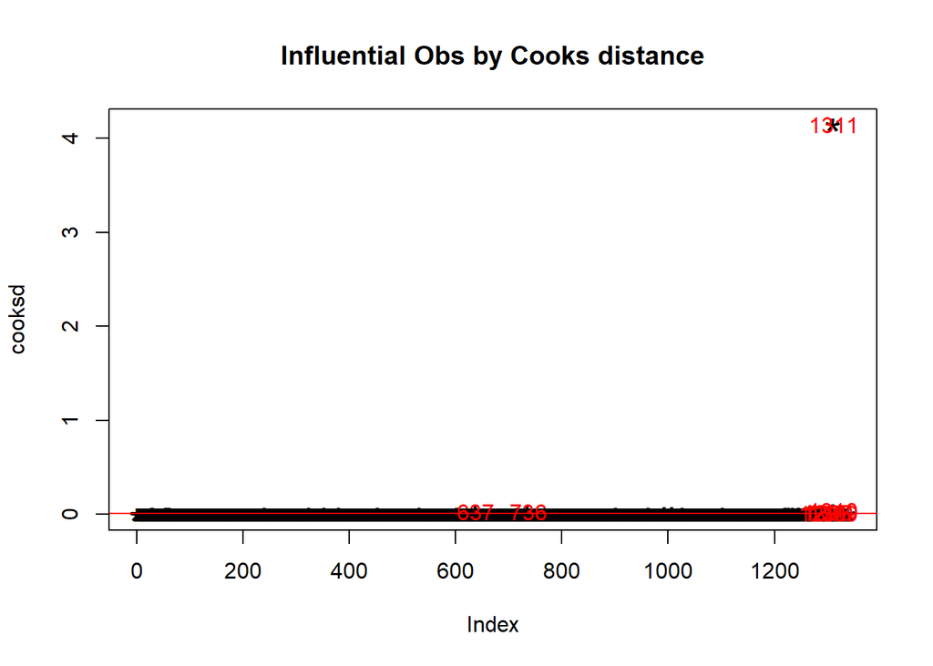

```r
cooksd <- cooks.distance(model)

plot(cooksd, pch="*", cex=2, main="Influential Obs by Cooks distance")
abline(h = 3*mean(cooksd, na.rm=T), col="red")
text(x=1:length(cooksd)+1, y=cooksd, labels=ifelse(cooksd>4*mean(cooksd, na.rm=T),names(cooksd),""), col="red")
```

```r
coffe_clean <- coffee_relevant[-1311, ]
```

```r
model<- lm(total_cup_points ~ aroma+ flavor+aftertaste+acidity+body+balance+uniformity+clean_cup+sweetness+cupper_points, data = coffe_clean)
summary(model)
```

```
##
## Call:
## lm(formula = total_cup_points ~ aroma + flavor + aftertaste +
##     acidity + body + balance + uniformity + clean_cup + sweetness +
##     cupper_points, data = coffe_clean)
##
## Residuals:
##     Min      1Q  Median      3Q     Max
## -3.3578 -1.0382 -0.0382  0.9618  2.7509
##
## Coefficients:
##               Estimate Std. Error t value Pr(>|t|)
## (Intercept)   11.66453    1.04275  11.186  < 2e-16 ***
## aroma          0.90423    0.11150   8.109 1.15e-15 ***
## flavor         0.75904    0.13237   5.734 1.21e-08 ***
## aftertaste     1.33227    0.12509  10.650  < 2e-16 ***
## acidity        0.95608    0.11458   8.344  < 2e-16 ***
## body           0.67214    0.12349   5.443 6.24e-08 ***
## balance        0.90008    0.10972   8.203 5.47e-16 ***
## uniformity     0.88853    0.06061  14.660  < 2e-16 ***
## clean_cup      0.94729    0.04677  20.254  < 2e-16 ***
## sweetness      0.70414    0.05122  13.747  < 2e-16 ***
## cupper_points  0.90104    0.08821  10.214  < 2e-16 ***
## ---
## Signif. codes:  0 '***' 0.001 '**' 0.01 '*' 0.05 '.' 0.1 ' ' 1
##
## Residual standard error: 1.141 on 1327 degrees of freedom
## Multiple R-squared:  0.8226, Adjusted R-squared:  0.8213
## F-statistic: 615.3 on 10 and 1327 DF,  p-value: < 2.2e-16
```

## Assumption checking

### Linearity

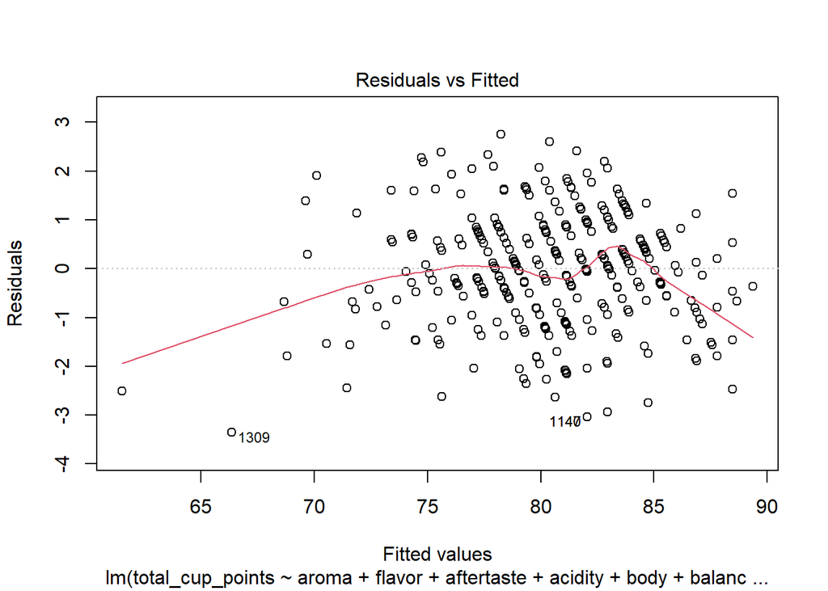

```r
plot(model, which =1 )
```

### Normality of residual

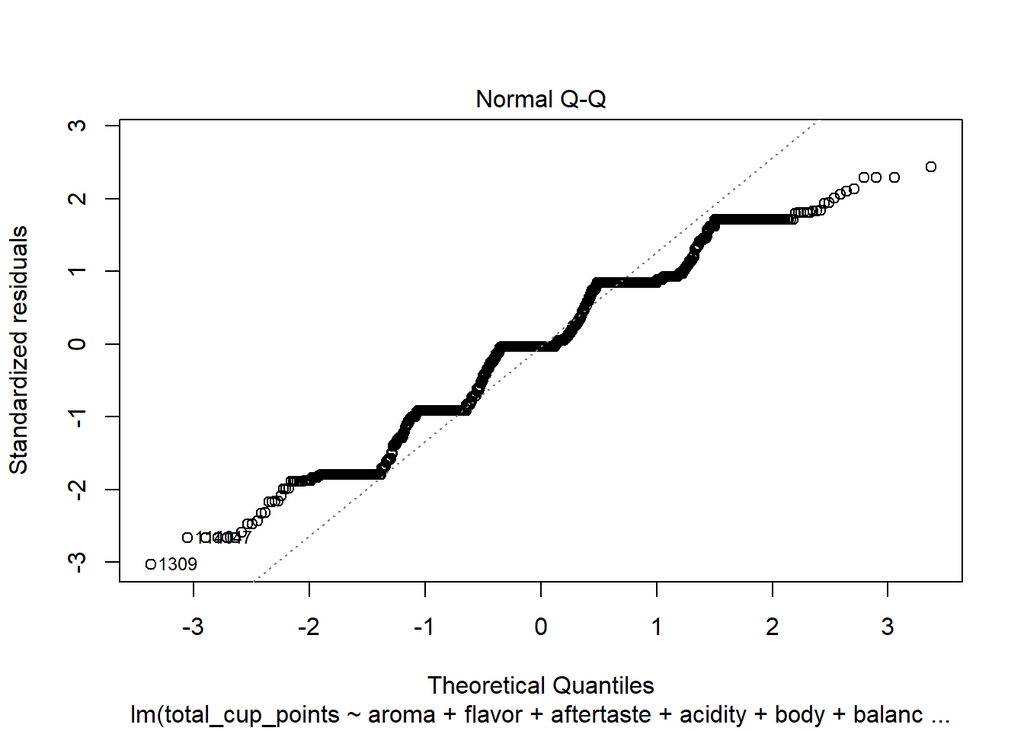

```r
plot(model, which = 2)
```

### Homogenety of variance

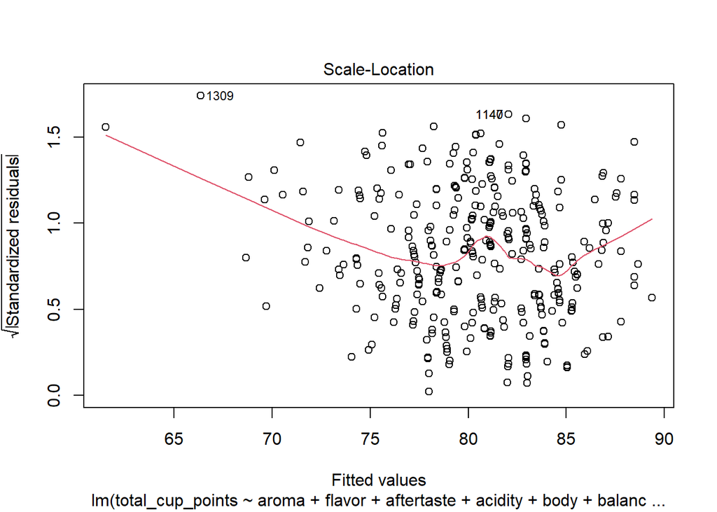

```r
plot(model, which=3)
```

### Multicolinearity

```r
vif(model)
```

```
##         aroma        flavor    aftertaste       acidity          body
##      1.500269      2.274755      2.176662      1.552707      1.382658
##       balance    uniformity     clean_cup     sweetness cupper_points
##      1.760695      1.305548      1.416718      1.170113      1.739286
```

All variables have VIF below 5 which mean that there is no problem with multicolinearity .

## Model comparison

### Model 1- simple

```r
model1 <- lm(total_cup_points ~ aftertaste + acidity+clean_cup, data = coffe_clean)

summary(model1)
```

```
##
## Call:
## lm(formula = total_cup_points ~ aftertaste + acidity + clean_cup,
##     data = coffe_clean)
##
## Residuals:
##     Min      1Q  Median      3Q     Max
## -7.8498 -1.0302 -0.0302  0.9698  6.1041
##
## Coefficients:
##             Estimate Std. Error t value Pr(>|t|)
## (Intercept) 30.55976    1.01485   30.11   <2e-16 ***
## aftertaste   3.18871    0.13062   24.41   <2e-16 ***
## acidity      2.03781    0.13680   14.90   <2e-16 ***
## clean_cup    1.48848    0.05449   27.31   <2e-16 ***
## ---
## Signif. codes:  0 '***' 0.001 '**' 0.01 '*' 0.05 '.' 0.1 ' ' 1
##
## Residual standard error: 1.516 on 1334 degrees of freedom
## Multiple R-squared:  0.6854, Adjusted R-squared:  0.6847
## F-statistic: 968.9 on 3 and 1334 DF,  p-value: < 2.2e-16
```

The model simultaneously can predict after cup points with F(3, 1334)=968,9, p<0.001. All predictors can explain 68% variance of the total cup of points.

### Model 2 : complex

```r
model2 <- lm(total_cup_points ~ aftertaste + acidity+clean_cup+aroma+balance+uniformity, data=coffe_clean)
summary(model2)
```

```
##
## Call:
## lm(formula = total_cup_points ~ aftertaste + acidity + clean_cup +
##     aroma + balance + uniformity, data = coffe_clean)
##
## Residuals:
##    Min     1Q Median     3Q    Max
## -7.407 -1.029 -0.029  0.971  3.505
##
## Coefficients:
##             Estimate Std. Error t value Pr(>|t|)
## (Intercept) 18.50778    1.03538  17.875   <2e-16 ***
## aftertaste   2.00004    0.12893  15.512   <2e-16 ***
## acidity      1.43519    0.12397  11.577   <2e-16 ***
## clean_cup    1.13358    0.05101  22.224   <2e-16 ***
## aroma        1.17868    0.12161   9.693   <2e-16 ***
## balance      1.39347    0.11802  11.807   <2e-16 ***
## uniformity   1.01337    0.06747  15.019   <2e-16 ***
## ---
## Signif. codes:  0 '***' 0.001 '**' 0.01 '*' 0.05 '.' 0.1 ' ' 1
##
## Residual standard error: 1.298 on 1331 degrees of freedom
## Multiple R-squared:  0.7698, Adjusted R-squared:  0.7687
## F-statistic: 741.7 on 6 and 1331 DF,  p-value: < 2.2e-16
```

```r
anova(model1, model2)
```

```
## Analysis of Variance Table
##
## Model 1: total_cup_points ~ aftertaste + acidity + clean_cup
## Model 2: total_cup_points ~ aftertaste + acidity + clean_cup + aroma +
##     balance + uniformity
##   Res.Df    RSS Df Sum of Sq      F    Pr(>F)
## 1   1334 3065.8
## 2   1331 2243.8  3    822.06 162.55 < 2.2e-16 ***
## ---
## Signif. codes:  0 '***' 0.001 '**' 0.01 '*' 0.05 '.' 0.1 ' ' 1
```

```r
sum_model1 <- glance(model1)
sum_model2 <- glance(model2)

comparison_mod <- sum_model1%>%
  rbind(sum_model2) %>%
  mutate(model= c ("simple", "complex")) %>%
  relocate (model) %>%
  as.data.frame()
comparison_mod
```

```
##     model r.squared adj.r.squared    sigma statistic p.value df    logLik
## 1  simple 0.6854248     0.6847174 1.515995  968.8798       0  3 -2453.241
## 2 complex 0.7697727     0.7687349 1.298383  741.7073       0  6 -2244.409
##        AIC      BIC deviance df.residual nobs
## 1 4916.483 4942.478 3065.855        1334 1338
## 2 4504.818 4546.409 2243.799        1331 1338
```